# Project1 - Spooky Analysis

Jerome Kafrouni-jk4100

February 5, 2018

# Section 0: Installing and loading packages

```r
packages.used <- c("ggplot2", "dplyr", "tibble", "tidyr",  "stringr", "tidytext", "topicmodels", "wordcloud", "ggridges", "rJava", "NLP", "openNLP", "textstem", "qdapDictionaries", "lexicon", "syllable", "readability", "randomForest")

# check packages that need to be installed.
packages.needed <- setdiff(packages.used, intersect(installed.packages()[,1], packages.used))

# install additional packages
if(length(packages.needed) > 0) {
  install.packages(packages.needed, dependencies = TRUE, repos = 'http://cran.us.r-project.org')
}

library(ggplot2)
library(dplyr)
library(tibble)
library(tidyr)
library(stringr)
library(tidytext)
library(topicmodels)
library(wordcloud)
library(ggridges)

source("../lib/multiplot.R")

library(textstem)
library(qdapDictionaries)
library(lexicon)
library(syllable)
library(readability)
library(randomForest)
```

## Part of Speech

You might have trouble installing the requirements for Part of Speech analysis (Section 4), especially if running on Mac. The steps necessary to make rJava work can be found here: https://github.com/snowflakedb/dplyr-snowflakedb/wiki/Configuring-R-rJava-RJDBC-on-Mac-OS-X. One main step is to launch R from the terminal and specify where to find rJava, with: “LD_LIBRARY_PATH=`/usr/libexec/java_home`/jre/lib/server open -a rstudio”.

```r
# Part of Speech:

install.packages("openNLPmodels.en", repos="http://datacube.wu.ac.at/" , type="source")
library(rJava)
library(NLP)
```

```r
library(openNLP)
library(openNLPmodels.en)
# NLP and ggplot2 both have a function named "annotate" which can cause a problem
# loading NLP after ggplot seems to fix the problem.
```

# Section 1: Data preparation

## 1.1 - Read in the data

The following code assumes that the dataset `spooky.csv` lives in a `data` folder (and that we are inside a `docs` folder).

```r
spooky <- read.csv('../data/spooky.csv', as.is = TRUE)
```

## 1.2 - Tokenization

We tokenize the text in multiple ways that will be useful in our analysis: Unigrams, with or without stopwords, bigrams.

```r
# Make a table with one word per row and remove `stop words` (i.e. the common words).
spooky_wrd <- unnest_tokens(spooky, word, text)
spooky_wrd <- anti_join(spooky_wrd, stop_words, by = "word")

spooky_wrd_with_stopwords <- unnest_tokens(spooky, word, text)

spooky_bigrams <- unnest_tokens(spooky, bigram, text, token = "ngrams", n = 2)
```

## 1.3 - Lemmatization

We perform lemmatization, ie reduce the inflected forms of words to the corresponding lemma. For example, if an author uses “is”, “are” and “was”, these three words will be reduced to the same lemma “be”. Lemmatization is more costly to perform than stemming, which doesn’t take the context into account, but since our corpus is relatively small, we can perform lemmatization in a decent time.

```r
# the textstem package has two main methods, lemmatize_words or lemmatize_sentences
spooky$lemmatized_text <- lemmatize_strings(spooky$text) # takes 30 sec
```

We generate bigrams on the lemmas that we just extracted:

```r
spooky_lemmatized_bigrams <- unnest_tokens(spooky, bigram, lemmatized_text, token = "ngrams", n = 2)
```

# Section 2: Comparing the authors quantitatively

We will extract numerical features from the data to compare the authors numerically.

## 2.1 - Generating and plotting the features

### 2.1.1 - Punctuation

```r
spooky <- cbind(spooky, commas = mapply(function(x) str_count(x, ","), spooky$text))
spooky <- cbind(spooky, semi_colons = mapply(function(x) str_count(x, ";"), spooky$text))
spooky <- cbind(spooky, colons = mapply(function(x) str_count(x, ":"), spooky$text)) # not interesting
spooky <- cbind(spooky, question = mapply(function(x) str_count(x, "\\?") > 0, spooky$text))
spooky <- cbind(spooky, exclamation = mapply(function(x) str_count(x, "\\!") > 0, spooky$text)) # not interesting
aggregate(commas ~ author, spooky, mean)
```

```
##   author   commas
## 1    EAP 2.227089
## 2    HPL 1.522804
## 3    MWS 1.992886
```

```r
aggregate(semi_colons ~ author, spooky, mean)
```

```
##   author semi_colons
## 1    EAP   0.1713924
## 2    HPL   0.2028394
## 3    MWS   0.4404368
```

```r
aggregate(colons ~ author, spooky, mean)
```

```
##   author      colons
## 1    EAP 0.022278481
## 2    HPL 0.008340728
## 3    MWS 0.056088683
```

```r
aggregate(question ~ author, spooky, mean)
```

```
##   author   question
## 1    EAP 0.05835443
## 2    HPL 0.02910382
## 3    MWS 0.06634679
```

```r
aggregate(exclamation ~ author, spooky, mean)
```

```
##   author exclamation
## 1    EAP           0
## 2    HPL           0
## 3    MWS           0
```

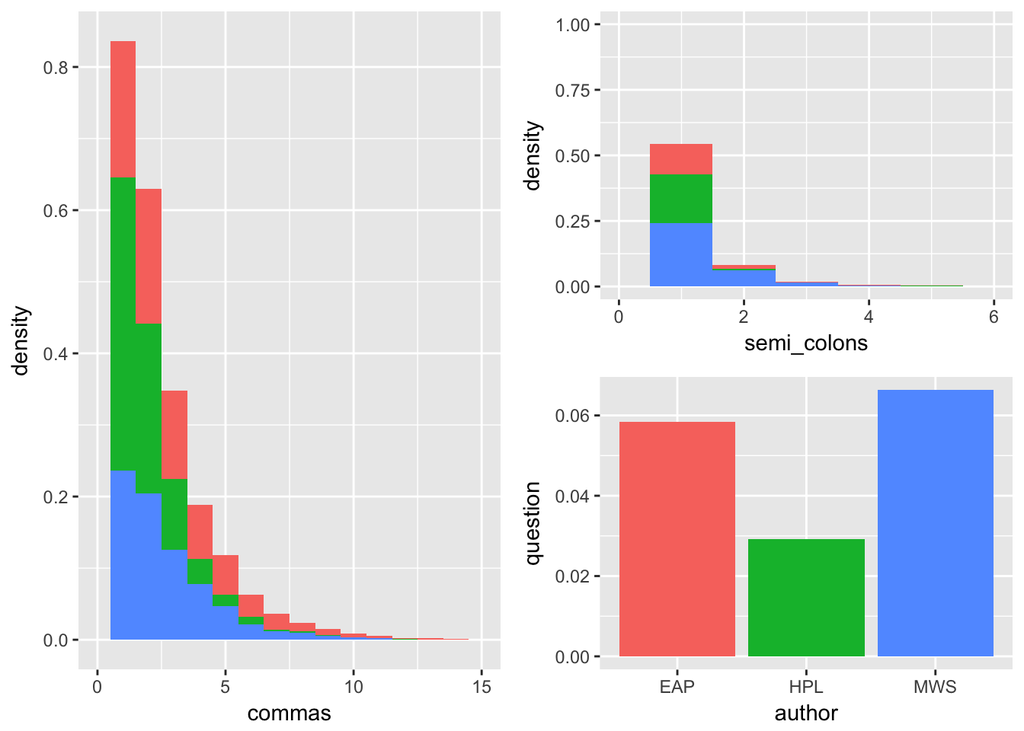

```r
# Plot densities (they do not sum to 1 but it's not a problem)

p1 <- ggplot(spooky[spooky$commas < 15,], aes(x = commas, y = ..density.., fill = author)) +
      xlim(c(0, 15)) +
      geom_histogram(binwidth=1) +
      theme(legend.position = "none")

p2 <- ggplot(spooky[spooky$semi_colons < 6,], aes(x = semi_colons, y = ..density.., fill = author)) +
      xlim(c(0, 6)) +
      ylim(c(0,1)) +
      geom_histogram(binwidth=1) +
      theme(legend.position = "none")


p3 <- ggplot(aggregate(question ~ author, spooky, mean), aes(x = author, y = question, fill = author)) +
      geom_bar(stat="identity") +
      theme(legend.position = "none")

# p4 <- ggplot(spooky[spooky$colons < 3,], aes(x = colons, y = ..density.., fill = author)) +
#       xlim(c(0, 3)) +
#       ylim(c(0,0.25)) +
#       geom_histogram() +
#       theme(legend.position = "none")


# p5 <- ggplot(aggregate(exclamation ~ author, spooky, sum), aes(x = author, y = exclamation, fill = author)) +
#       geom_bar(stat="identity") +
#       theme(legend.position = "none")

layout <- matrix(c(1, 2, 1, 3), 2, 2, byrow = TRUE)
multiplot(p1, p2, p3, layout = layout)
```

We notice that these sentences contain no exclamation mark. This result is odd, and might come from how the data was collected or encoded (to generate the csv file). We also notice that authors almost do not use colons, which was not expected. For this reason, we did not plot these two variables.

Among these three variables, one that is very interesting is questions: HP Lovecraft seems to use much less (almost twice less) questions than Mary Shelly or Edgar Allan Poe. We’ll see in Section 4 that one reason might be that HP Lovecraft uses less dialogue.

### 2.1.2 - Punctuation words ratio

The use of punctuation seems to be quite specific to each author. We looked at how each author uses each punctuation sign, let’s now look at how often they use punctuation in general.

To compute this feature, we split the strings using the regex “\W+” This is the most direct way to do it, Otherwise we could use the dataframe spooky_wrd (group by id, count, and join with spooky)

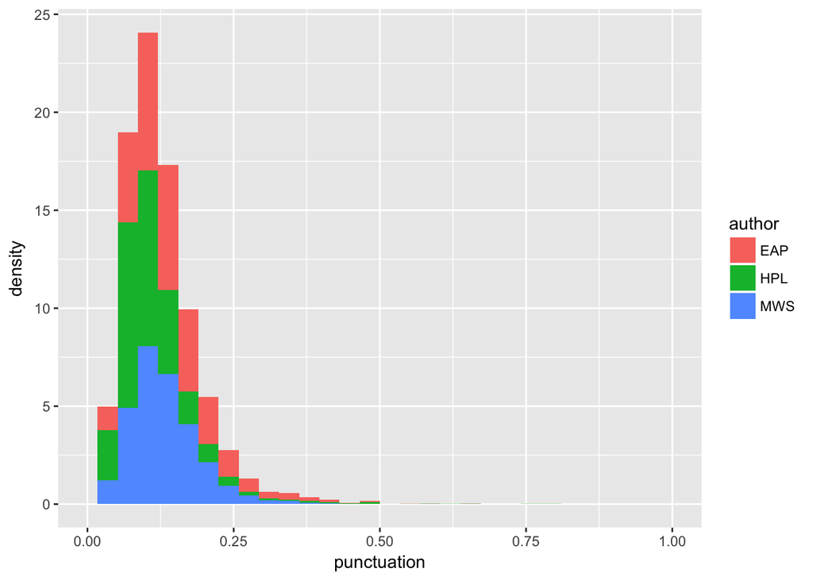

```r
spooky <- cbind(spooky, punctuation = mapply(function(x) str_count(x, "[?!,;:.-]") / (str_count(x, "\\W+") + 1), spooky$text))

ggplot(spooky, aes(x = punctuation, y = ..density.., fill = author)) +
      geom_histogram() +
      xlim(c(0,1))
```

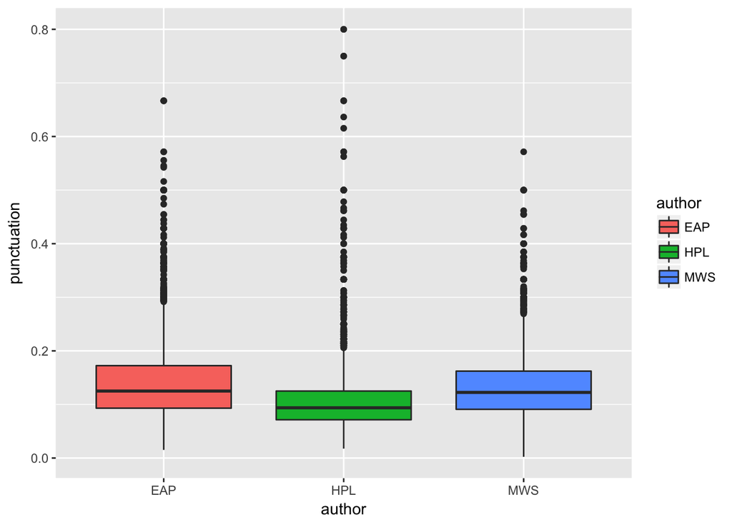

```r
ggplot(spooky[spooky$punctuation < 1,], aes(x = author, y = punctuation, fill = author)) +
  geom_boxplot()
```

We notice that, on average, HP Lovecraft uses less punctuation, and the variance of the punctuation frequency is lower for him, which means that he tends to use often the same amount of punctuation. Note that we got rid of outliers that come from the data (csv) preparation.

### 2.1.3 - Uppercase

One interesting feature may also be how often do authors use uppercase letters. To normalize this feature, we’ll actually look at the ratio of uppercase vs lowercase characters in each sentence. This will also prevent from outliers, since it seems that some sentences have not been split correctly (see 2.1.4 - sentence length, below).

```r
# Number of uppercase characters divided by length of sentence
spooky <- cbind(spooky, uppercase_freq = mapply(function(x) str_count(x, "[A-Z]") / str_length(x), spooky$text))
aggregate(uppercase_freq ~ author, spooky, mean)
```

```
##   author uppercase_freq
## 1    EAP     0.02085997
## 2    HPL     0.01823695
## 3    MWS     0.01853871
```

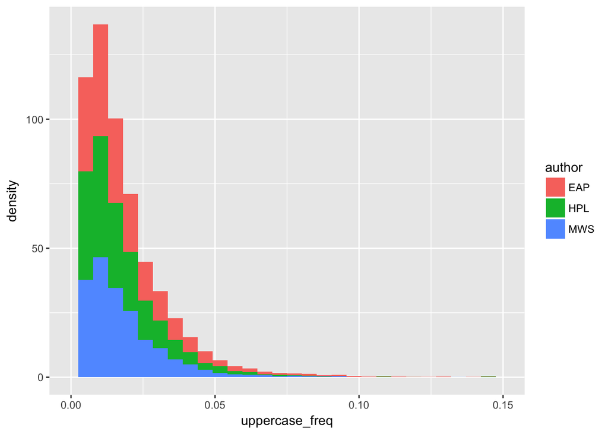

```r
ggplot(spooky[spooky$uppercase_freq < 0.15,]) +
  geom_histogram(aes(x = uppercase_freq, y = ..density.., fill = author)) +
  xlim(c(0, 0.15))
```

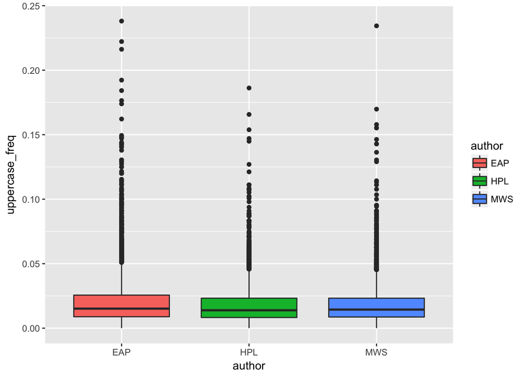

```r
ggplot(spooky[spooky$uppercase_freq < 0.25,], aes(x = author, y = uppercase_freq, fill = author)) +
  geom_boxplot()
```

Uppercase doesn’t seem to be very informative, it seems that they have quite similar distributions for this variable which means that they use uppercase the same way. Differences on the use of uppercase would have been helpful for example to know if authors tend to use more entities, names for example. Even though we canno conclude here, we’ll have a deeper look at this in the following sections.

### 2.1.4 - Sentence length

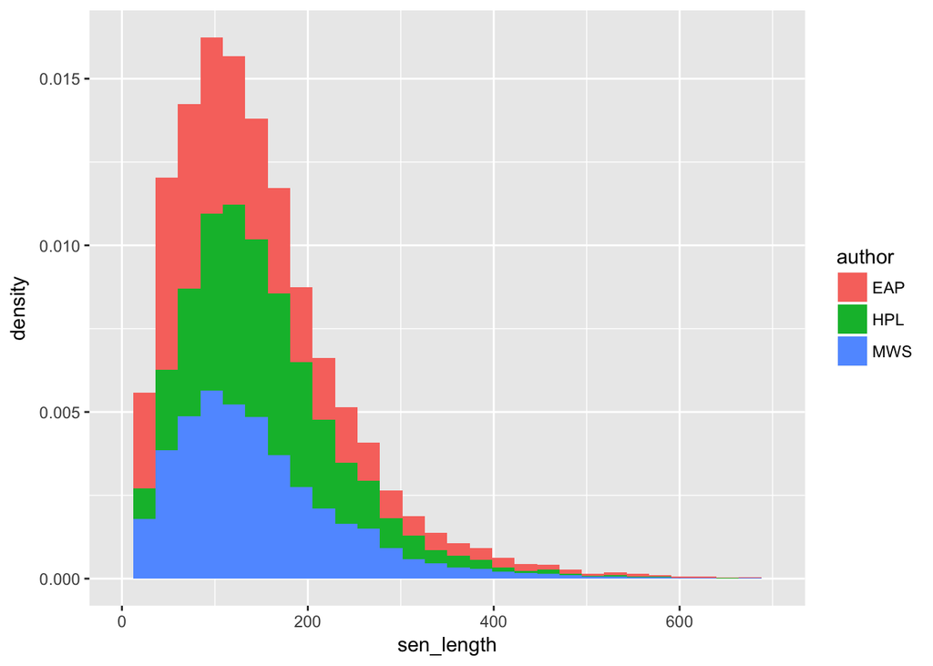

```r
spooky$sen_length <- str_length(spooky$text)

ggplot(spooky, aes(x = sen_length, y = ..density.., fill = author)) +
  geom_histogram() +
  xlim(c(0,700))
```

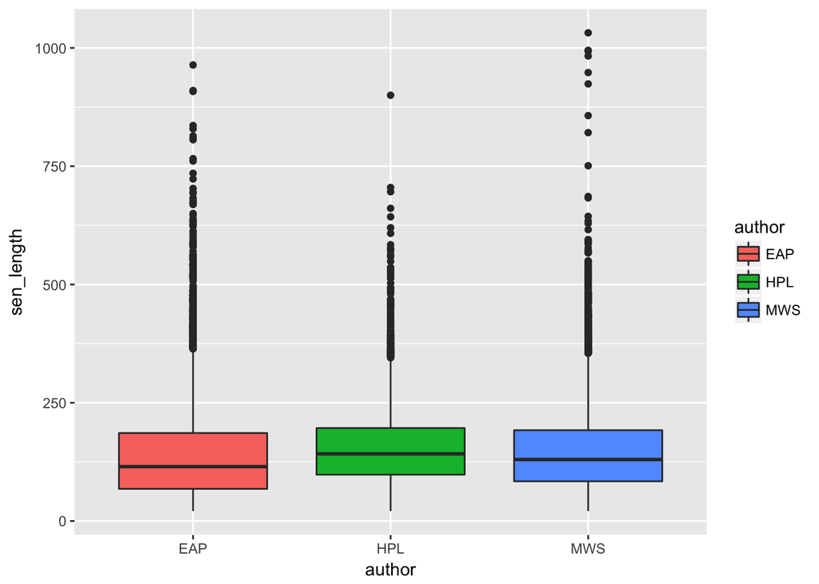

```r
ggplot(spooky[spooky$sen_length < 1200,], aes(x = author, y = sen_length, fill = author)) +
  geom_boxplot()
```

HP Lovecraft seems to use slightly longer sentences on average.

### 2.1.5 - Average word length in sentence

Now that we have compared lengths of sentences, let’s look at length of the words themselves. Instead of just looking at words individually (which we have done in the in-class tutorial), we’ll look at the average length of words in each sentence.

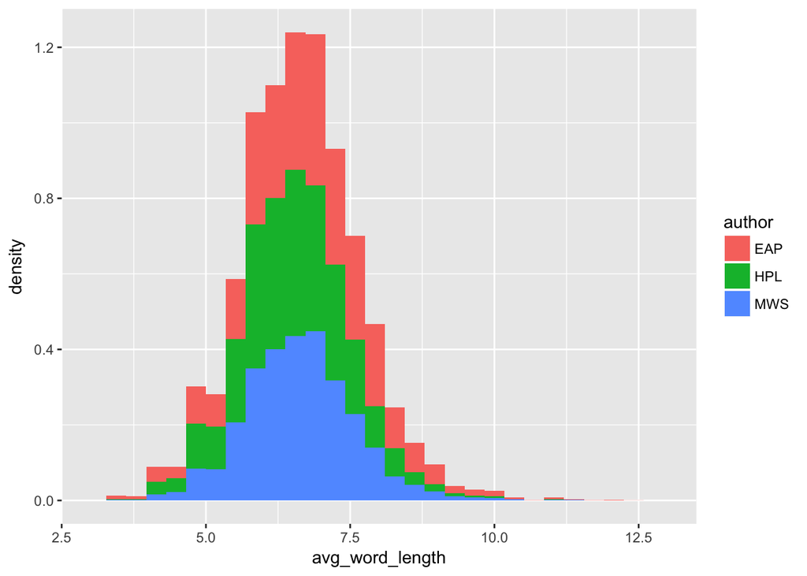

```r
lengths <- spooky_wrd  %>% group_by(id) %>% summarise(avg_word_length = mean(str_length(word)))
spooky <- inner_join(lengths, spooky, by="id")

ggplot(spooky, aes(x = avg_word_length, y = ..density.., fill = author)) +
  geom_histogram() +
  xlim(c(3,13))
```

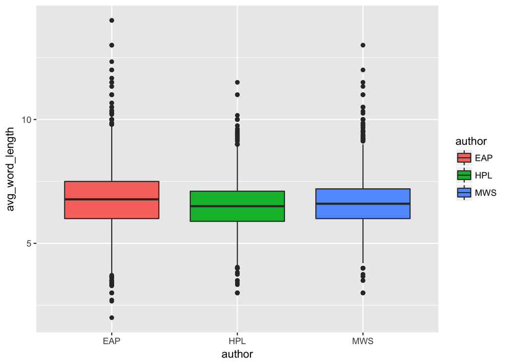

```r
ggplot(spooky[spooky$avg_word_length < 15,], aes(x = author, y = avg_word_length, fill = author)) +
  geom_boxplot()
```

The three distributions are quite similar, with higher variance for Edgar Allan Poe which means that he’s less constant in the length of the words that he uses and often uses either very short or very long words.

### 2.1.6 - Readability

The last feature that we’ll generate is a summary of the previous features concerning string lengths: There exist several indexes to measure how “readable” sentences are, which compare the number of syllables of the words used and the length of the sentence. These indexes estimate the years of formal education a person needs to understand the text on the first reading.

The fog index is commonly used to confirm that text can be read easily by the intended audience. Texts for a wide audience generally need a fog index less than 12. Texts requiring near-universal understanding generally need an index less than 8.

Gunning Fog: 12 = High school senior | 14 = College sophomore | 17 = College graduate

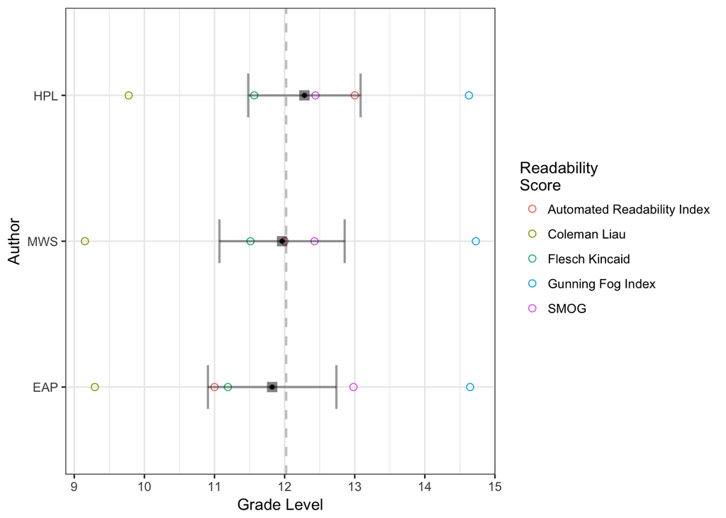

```r
x <- with(spooky, readability(text, author))
plot(x)
```

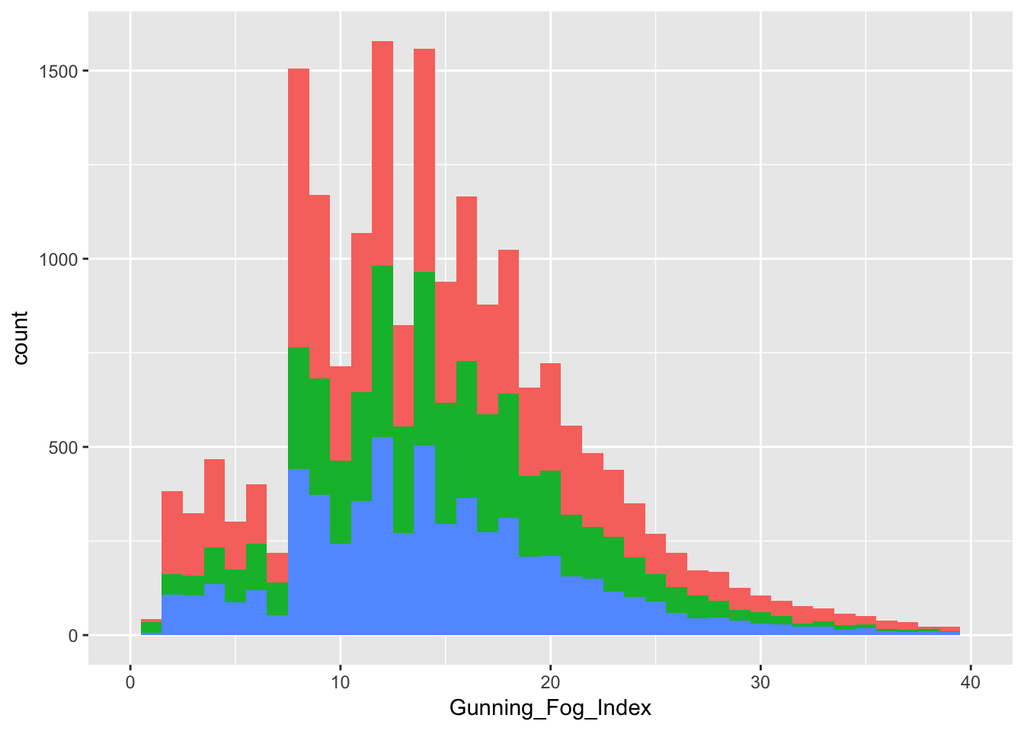

```r
x2 <- with(spooky, readability(text, list(author, id)))

ggplot(x2, aes(x = Gunning_Fog_Index, fill = author)) +
      geom_histogram(binwidth=1) +
      xlim(c(0, 40)) + # there are outliers
      theme(legend.position = "none")
```

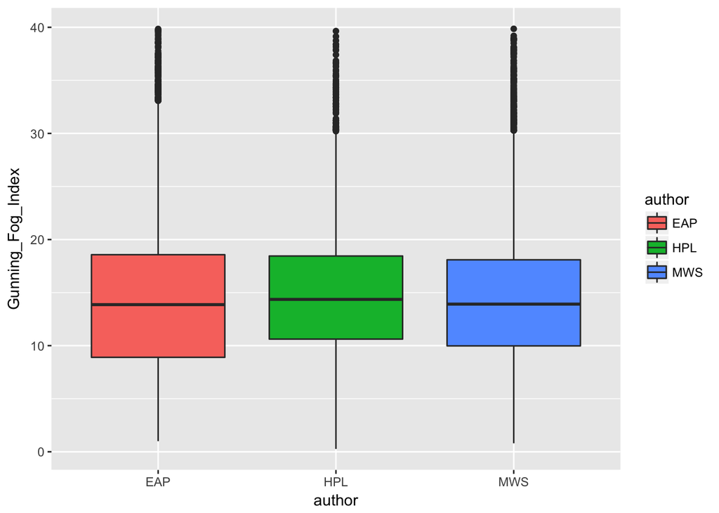

```r
ggplot(x2[x2$Gunning_Fog_Index < 40,], aes(x = author, y = Gunning_Fog_Index, fill = author)) +
  geom_boxplot()
```

Readability doesn’t seem to be very informative about the authors, the distributions are close, with a slightly higher variance for Edgar Allan Poe.